# Risk Factor Analysis

## Outcome Variable

**Outcome Variable:** sstunted

## Predictor Variables

**Intervention Variable:** mbmi

**Adjustment Set:**

- arm
- W_mage
- W_fage
- meducyrs
- feducyrs
- single
- brthmon
- delta_W_mage
- delta_W_fage
- delta_meducyrs
- delta_feducyrs
- delta_single
- delta_brthmon

## Stratifying Variables

The analysis was stratified on these variable(s):

- agecat
- studyid
- country

## Data Summary

| agecat | studyid | country | mbmi | sstunted | n_cell | n |
| --- | --- | --- | --- | --- | --- | --- |
| Birth | ki0047075b-MAL-ED | BANGLADESH | Normal weight | 0 | 153 | 246 |
| Birth | ki0047075b-MAL-ED | BANGLADESH | Normal weight | 1 | 5 | 246 |
| Birth | ki0047075b-MAL-ED | BANGLADESH | Underweight | 0 | 29 | 246 |
| Birth | ki0047075b-MAL-ED | BANGLADESH | Underweight | 1 | 1 | 246 |
| Birth | ki0047075b-MAL-ED | BANGLADESH | Overweight or Obese | 0 | 57 | 246 |
| Birth | ki0047075b-MAL-ED | BANGLADESH | Overweight or Obese | 1 | 1 | 246 |
| Birth | ki0047075b-MAL-ED | BRAZIL | Normal weight | 0 | 68 | 184 |
| Birth | ki0047075b-MAL-ED | BRAZIL | Normal weight | 1 | 2 | 184 |
| Birth | ki0047075b-MAL-ED | BRAZIL | Underweight | 0 | 9 | 184 |
| Birth | ki0047075b-MAL-ED | BRAZIL | Underweight | 1 | 0 | 184 |
| Birth | ki0047075b-MAL-ED | BRAZIL | Overweight or Obese | 0 | 99 | 184 |
| Birth | ki0047075b-MAL-ED | BRAZIL | Overweight or Obese | 1 | 6 | 184 |
| Birth | ki0047075b-MAL-ED | INDIA | Normal weight | 0 | 112 | 198 |
| Birth | ki0047075b-MAL-ED | INDIA | Normal weight | 1 | 5 | 198 |
| Birth | ki0047075b-MAL-ED | INDIA | Underweight | 0 | 37 | 198 |
| Birth | ki0047075b-MAL-ED | INDIA | Underweight | 1 | 2 | 198 |
| Birth | ki0047075b-MAL-ED | INDIA | Overweight or Obese | 0 | 42 | 198 |
| Birth | ki0047075b-MAL-ED | INDIA | Overweight or Obese | 1 | 0 | 198 |
| Birth | ki0047075b-MAL-ED | NEPAL | Normal weight | 0 | 94 | 172 |
| Birth | ki0047075b-MAL-ED | NEPAL | Normal weight | 1 | 5 | 172 |
| Birth | ki0047075b-MAL-ED | NEPAL | Underweight | 0 | 0 | 172 |
| Birth | ki0047075b-MAL-ED | NEPAL | Underweight | 1 | 0 | 172 |
| Birth | ki0047075b-MAL-ED | NEPAL | Overweight or Obese | 0 | 72 | 172 |
| Birth | ki0047075b-MAL-ED | NEPAL | Overweight or Obese | 1 | 1 | 172 |
| Birth | ki0047075b-MAL-ED | PERU | Normal weight | 0 | 147 | 276 |
| Birth | ki0047075b-MAL-ED | PERU | Normal weight | 1 | 2 | 276 |
| Birth | ki0047075b-MAL-ED | PERU | Underweight | 0 | 4 | 276 |
| Birth | ki0047075b-MAL-ED | PERU | Underweight | 1 | 1 | 276 |
| Birth | ki0047075b-MAL-ED | PERU | Overweight or Obese | 0 | 118 | 276 |
| Birth | ki0047075b-MAL-ED | PERU | Overweight or Obese | 1 | 4 | 276 |

[output cut: 216 more lines]

The following strata were considered:

- agecat: 24 months, studyid: ki0047075b-MAL-ED, country: BANGLADESH
- agecat: 24 months, studyid: ki0047075b-MAL-ED, country: BRAZIL
- agecat: 24 months, studyid: ki0047075b-MAL-ED, country: INDIA
- agecat: 24 months, studyid: ki0047075b-MAL-ED, country: NEPAL
- agecat: 24 months, studyid: ki0047075b-MAL-ED, country: PERU
- agecat: 24 months, studyid: ki0047075b-MAL-ED, country: SOUTH AFRICA
- agecat: 24 months, studyid: ki0047075b-MAL-ED, country: TANZANIA, UNITED REPUBLIC OF
- agecat: 24 months, studyid: ki1017093-NIH-Birth, country: BANGLADESH
- agecat: 24 months, studyid: ki1017093b-PROVIDE, country: BANGLADESH
- agecat: 24 months, studyid: ki1017093c-NIH-Crypto, country: BANGLADESH
- agecat: 24 months, studyid: ki1066203-TanzaniaChild2, country: TANZANIA, UNITED REPUBLIC OF
- agecat: 24 months, studyid: ki1119695-PROBIT, country: BELARUS
- agecat: 24 months, studyid: ki1126311-ZVITAMBO, country: ZIMBABWE
- agecat: 24 months, studyid: ki1148112-LCNI-5, country: MALAWI
- agecat: 6 months, studyid: ki0047075b-MAL-ED, country: BANGLADESH
- agecat: 6 months, studyid: ki0047075b-MAL-ED, country: BRAZIL
- agecat: 6 months, studyid: ki0047075b-MAL-ED, country: INDIA
- agecat: 6 months, studyid: ki0047075b-MAL-ED, country: NEPAL
- agecat: 6 months, studyid: ki0047075b-MAL-ED, country: PERU
- agecat: 6 months, studyid: ki0047075b-MAL-ED, country: SOUTH AFRICA
- agecat: 6 months, studyid: ki0047075b-MAL-ED, country: TANZANIA, UNITED REPUBLIC OF
- agecat: 6 months, studyid: ki1000304b-SAS-CompFeed, country: INDIA
- agecat: 6 months, studyid: ki1017093-NIH-Birth, country: BANGLADESH
- agecat: 6 months, studyid: ki1017093b-PROVIDE, country: BANGLADESH
- agecat: 6 months, studyid: ki1017093c-NIH-Crypto, country: BANGLADESH
- agecat: 6 months, studyid: ki1066203-TanzaniaChild2, country: TANZANIA, UNITED REPUBLIC OF
- agecat: 6 months, studyid: ki1119695-PROBIT, country: BELARUS
- agecat: 6 months, studyid: ki1126311-ZVITAMBO, country: ZIMBABWE
- agecat: 6 months, studyid: ki1148112-LCNI-5, country: MALAWI
- agecat: Birth, studyid: ki0047075b-MAL-ED, country: BANGLADESH
- agecat: Birth, studyid: ki0047075b-MAL-ED, country: BRAZIL
- agecat: Birth, studyid: ki0047075b-MAL-ED, country: INDIA
- agecat: Birth, studyid: ki0047075b-MAL-ED, country: NEPAL
- agecat: Birth, studyid: ki0047075b-MAL-ED, country: PERU
- agecat: Birth, studyid: ki0047075b-MAL-ED, country: SOUTH AFRICA
- agecat: Birth, studyid: ki0047075b-MAL-ED, country: TANZANIA, UNITED REPUBLIC OF
- agecat: Birth, studyid: ki1000304b-SAS-CompFeed, country: INDIA
- agecat: Birth, studyid: ki1017093-NIH-Birth, country: BANGLADESH
- agecat: Birth, studyid: ki1017093c-NIH-Crypto, country: BANGLADESH
- agecat: Birth, studyid: ki1119695-PROBIT, country: BELARUS
- agecat: Birth, studyid: ki1126311-ZVITAMBO, country: ZIMBABWE

### Dropped Strata

Some strata were dropped due to rare outcomes:

- agecat: Birth, studyid: ki0047075b-MAL-ED, country: BANGLADESH
- agecat: Birth, studyid: ki0047075b-MAL-ED, country: BRAZIL
- agecat: Birth, studyid: ki0047075b-MAL-ED, country: INDIA
- agecat: Birth, studyid: ki0047075b-MAL-ED, country: NEPAL
- agecat: Birth, studyid: ki0047075b-MAL-ED, country: PERU
- agecat: Birth, studyid: ki0047075b-MAL-ED, country: SOUTH AFRICA
- agecat: Birth, studyid: ki0047075b-MAL-ED, country: TANZANIA, UNITED REPUBLIC OF
- agecat: Birth, studyid: ki1000304b-SAS-CompFeed, country: INDIA
- agecat: Birth, studyid: ki1017093-NIH-Birth, country: BANGLADESH
- agecat: Birth, studyid: ki1017093c-NIH-Crypto, country: BANGLADESH
- agecat: Birth, studyid: ki1119695-PROBIT, country: BELARUS
- agecat: 6 months, studyid: ki0047075b-MAL-ED, country: BANGLADESH
- agecat: 6 months, studyid: ki0047075b-MAL-ED, country: BRAZIL
- agecat: 6 months, studyid: ki0047075b-MAL-ED, country: INDIA
- agecat: 6 months, studyid: ki0047075b-MAL-ED, country: NEPAL
- agecat: 6 months, studyid: ki0047075b-MAL-ED, country: PERU
- agecat: 6 months, studyid: ki0047075b-MAL-ED, country: SOUTH AFRICA
- agecat: 6 months, studyid: ki0047075b-MAL-ED, country: TANZANIA, UNITED REPUBLIC OF
- agecat: 6 months, studyid: ki1000304b-SAS-CompFeed, country: INDIA
- agecat: 6 months, studyid: ki1017093-NIH-Birth, country: BANGLADESH
- agecat: 6 months, studyid: ki1017093b-PROVIDE, country: BANGLADESH
- agecat: 6 months, studyid: ki1066203-TanzaniaChild2, country: TANZANIA, UNITED REPUBLIC OF
- agecat: 6 months, studyid: ki1148112-LCNI-5, country: MALAWI
- agecat: 24 months, studyid: ki0047075b-MAL-ED, country: BANGLADESH
- agecat: 24 months, studyid: ki0047075b-MAL-ED, country: BRAZIL
- agecat: 24 months, studyid: ki0047075b-MAL-ED, country: INDIA
- agecat: 24 months, studyid: ki0047075b-MAL-ED, country: NEPAL
- agecat: 24 months, studyid: ki0047075b-MAL-ED, country: PERU
- agecat: 24 months, studyid: ki0047075b-MAL-ED, country: SOUTH AFRICA
- agecat: 24 months, studyid: ki0047075b-MAL-ED, country: TANZANIA, UNITED REPUBLIC OF
- agecat: 24 months, studyid: ki1017093b-PROVIDE, country: BANGLADESH
- agecat: 24 months, studyid: ki1066203-TanzaniaChild2, country: TANZANIA, UNITED REPUBLIC OF
- agecat: 24 months, studyid: ki1119695-PROBIT, country: BELARUS
- agecat: 24 months, studyid: ki1126311-ZVITAMBO, country: ZIMBABWE
- agecat: 24 months, studyid: ki1148112-LCNI-5, country: MALAWI

## Methods Detail

We’re interested in the causal parameters $E[Y_a]$ for all values of $a \in \mathcal{A}$. These parameters represent the mean outcome if, possibly contrary to fact, we intervened to set all units to have $A=a$. Under the randomization and positivity assumptions, these are identified by the statistical parameters $\psi_a=E_W[E_{Y|A,W}(Y|A=a,W)]$. In addition, we’re interested in the mean of $Y$, $E[Y]$ under no intervention (the observed mean). We will estimate these parameters by using SuperLearner to fit the relevant likelihood factors – $E_{Y|A,W}(Y|A=a,W)$ and $p(A=a|W)$, and then updating our likelihood fit using a joint TMLE.

For unadjusted analyses ($W=\{\}$), initial likelihoods were estimated using Lrnr_glm to estimate the simple $E(Y|A)$ and Lrnr_mean to estimate $p(A)$. For adjusted analyses, a small library containing Lrnr_glmnet, Lrnr_xgboost, and Lrnr_mean was used.

Having estimated these parameters, we will then use the delta method to estimate relative risks and attributable risks relative to a prespecified baseline level of $A$.

# Results Detail

## Results Plots

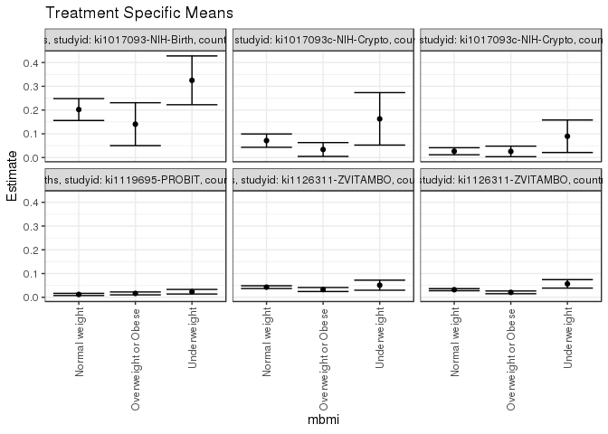

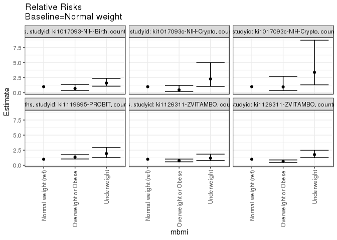

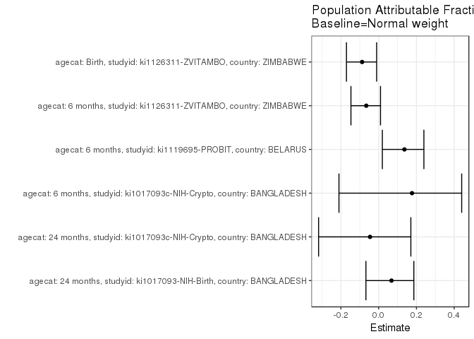

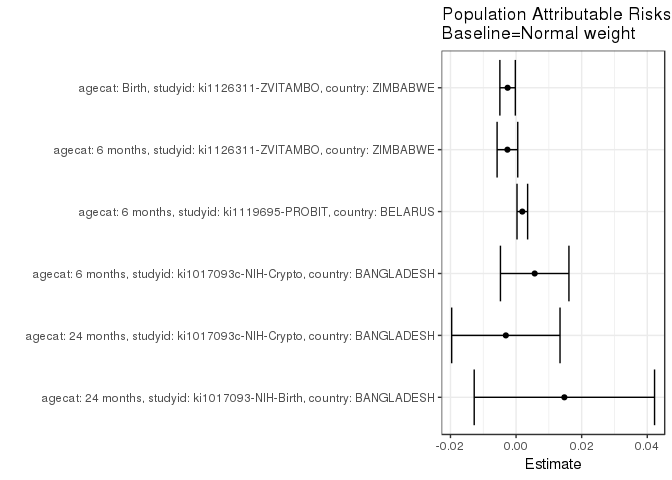

## Results Table

### Parameter: TSM

| agecat | studyid | country | intervention_level | baseline_level | estimate | ci_lower | ci_upper |
| --- | --- | --- | --- | --- | --- | --- | --- |
| Birth | ki1126311-ZVITAMBO | ZIMBABWE | Normal weight | NA | 0.0319530 | 0.0276491 | 0.0362569 |
| Birth | ki1126311-ZVITAMBO | ZIMBABWE | Underweight | NA | 0.0565788 | 0.0387764 | 0.0743811 |
| Birth | ki1126311-ZVITAMBO | ZIMBABWE | Overweight or Obese | NA | 0.0208027 | 0.0151423 | 0.0264631 |
| 6 months | ki1017093c-NIH-Crypto | BANGLADESH | Normal weight | NA | 0.0264901 | 0.0116917 | 0.0412885 |
| 6 months | ki1017093c-NIH-Crypto | BANGLADESH | Underweight | NA | 0.0895522 | 0.0211327 | 0.1579718 |
| 6 months | ki1017093c-NIH-Crypto | BANGLADESH | Overweight or Obese | NA | 0.0256410 | 0.0034406 | 0.0478415 |
| 6 months | ki1119695-PROBIT | BELARUS | Normal weight | NA | 0.0120650 | 0.0075620 | 0.0165680 |
| 6 months | ki1119695-PROBIT | BELARUS | Underweight | NA | 0.0234361 | 0.0137723 | 0.0331000 |
| 6 months | ki1119695-PROBIT | BELARUS | Overweight or Obese | NA | 0.0163035 | 0.0102012 | 0.0224059 |
| 6 months | ki1126311-ZVITAMBO | ZIMBABWE | Normal weight | NA | 0.0427252 | 0.0369601 | 0.0484903 |
| 6 months | ki1126311-ZVITAMBO | ZIMBABWE | Underweight | NA | 0.0509087 | 0.0297475 | 0.0720700 |
| 6 months | ki1126311-ZVITAMBO | ZIMBABWE | Overweight or Obese | NA | 0.0327709 | 0.0243556 | 0.0411862 |
| 24 months | ki1017093-NIH-Birth | BANGLADESH | Normal weight | NA | 0.2020548 | 0.1559459 | 0.2481637 |
| 24 months | ki1017093-NIH-Birth | BANGLADESH | Underweight | NA | 0.3250000 | 0.2222449 | 0.4277551 |
| 24 months | ki1017093-NIH-Birth | BANGLADESH | Overweight or Obese | NA | 0.1403509 | 0.0500721 | 0.2306296 |
| 24 months | ki1017093c-NIH-Crypto | BANGLADESH | Normal weight | NA | 0.0712074 | 0.0431342 | 0.0992806 |
| 24 months | ki1017093c-NIH-Crypto | BANGLADESH | Underweight | NA | 0.1627907 | 0.0523400 | 0.2732414 |
| 24 months | ki1017093c-NIH-Crypto | BANGLADESH | Overweight or Obese | NA | 0.0337838 | 0.0046477 | 0.0629199 |

### Parameter: E(Y)

| agecat | studyid | country | intervention_level | baseline_level | estimate | ci_lower | ci_upper |
| --- | --- | --- | --- | --- | --- | --- | --- |
| Birth | ki1126311-ZVITAMBO | ZIMBABWE | NA | NA | 0.0293751 | 0.0260032 | 0.0327471 |
| 6 months | ki1017093c-NIH-Crypto | BANGLADESH | NA | NA | 0.0321678 | 0.0192256 | 0.0451101 |
| 6 months | ki1119695-PROBIT | BELARUS | NA | NA | 0.0139710 | 0.0092040 | 0.0187379 |
| 6 months | ki1126311-ZVITAMBO | ZIMBABWE | NA | NA | 0.0400900 | 0.0355296 | 0.0446505 |
| 24 months | ki1017093-NIH-Birth | BANGLADESH | NA | NA | 0.2167832 | 0.1777459 | 0.2558205 |
| 24 months | ki1017093c-NIH-Crypto | BANGLADESH | NA | NA | 0.0680934 | 0.0462948 | 0.0898920 |

### Parameter: RR

| agecat | studyid | country | intervention_level | baseline_level | estimate | ci_lower | ci_upper |
| --- | --- | --- | --- | --- | --- | --- | --- |
| Birth | ki1126311-ZVITAMBO | ZIMBABWE | Normal weight | Normal weight | 1.0000000 | 1.0000000 | 1.0000000 |
| Birth | ki1126311-ZVITAMBO | ZIMBABWE | Underweight | Normal weight | 1.7706875 | 1.2577421 | 2.4928277 |
| Birth | ki1126311-ZVITAMBO | ZIMBABWE | Overweight or Obese | Normal weight | 0.6510405 | 0.4805514 | 0.8820154 |
| 6 months | ki1017093c-NIH-Crypto | BANGLADESH | Normal weight | Normal weight | 1.0000000 | 1.0000000 | 1.0000000 |
| 6 months | ki1017093c-NIH-Crypto | BANGLADESH | Underweight | Normal weight | 3.3805970 | 1.3120411 | 8.7104257 |
| 6 months | ki1017093c-NIH-Crypto | BANGLADESH | Overweight or Obese | Normal weight | 0.9679487 | 0.3454272 | 2.7123653 |
| 6 months | ki1119695-PROBIT | BELARUS | Normal weight | Normal weight | 1.0000000 | 1.0000000 | 1.0000000 |
| 6 months | ki1119695-PROBIT | BELARUS | Underweight | Normal weight | 1.9424937 | 1.2742862 | 2.9610945 |
| 6 months | ki1119695-PROBIT | BELARUS | Overweight or Obese | Normal weight | 1.3513124 | 1.0426796 | 1.7513005 |
| 6 months | ki1126311-ZVITAMBO | ZIMBABWE | Normal weight | Normal weight | 1.0000000 | 1.0000000 | 1.0000000 |
| 6 months | ki1126311-ZVITAMBO | ZIMBABWE | Underweight | Normal weight | 1.1915398 | 0.7697000 | 1.8445719 |
| 6 months | ki1126311-ZVITAMBO | ZIMBABWE | Overweight or Obese | Normal weight | 0.7670169 | 0.5739149 | 1.0250908 |
| 24 months | ki1017093-NIH-Birth | BANGLADESH | Normal weight | Normal weight | 1.0000000 | 1.0000000 | 1.0000000 |
| 24 months | ki1017093-NIH-Birth | BANGLADESH | Underweight | Normal weight | 1.6084746 | 1.0891148 | 2.3754983 |
| 24 months | ki1017093-NIH-Birth | BANGLADESH | Overweight or Obese | Normal weight | 0.6946179 | 0.3510210 | 1.3745447 |
| 24 months | ki1017093c-NIH-Crypto | BANGLADESH | Normal weight | Normal weight | 1.0000000 | 1.0000000 | 1.0000000 |
| 24 months | ki1017093c-NIH-Crypto | BANGLADESH | Underweight | Normal weight | 2.2861476 | 1.0430603 | 5.0107084 |
| 24 months | ki1017093c-NIH-Crypto | BANGLADESH | Overweight or Obese | Normal weight | 0.4744418 | 0.1838042 | 1.2246460 |

### Parameter: PAR

| agecat | studyid | country | intervention_level | baseline_level | estimate | ci_lower | ci_upper |
| --- | --- | --- | --- | --- | --- | --- | --- |
| Birth | ki1126311-ZVITAMBO | ZIMBABWE | Normal weight | NA | -0.0025779 | -0.0049352 | -0.0002205 |
| 6 months | ki1017093c-NIH-Crypto | BANGLADESH | Normal weight | NA | 0.0056778 | -0.0047626 | 0.0161182 |
| 6 months | ki1119695-PROBIT | BELARUS | Normal weight | NA | 0.0019060 | 0.0002877 | 0.0035243 |
| 6 months | ki1126311-ZVITAMBO | ZIMBABWE | Normal weight | NA | -0.0026351 | -0.0057826 | 0.0005123 |
| 24 months | ki1017093-NIH-Birth | BANGLADESH | Normal weight | NA | 0.0147284 | -0.0127628 | 0.0422196 |
| 24 months | ki1017093c-NIH-Crypto | BANGLADESH | Normal weight | NA | -0.0031140 | -0.0196303 | 0.0134022 |

### Parameter: PAF

| agecat | studyid | country | intervention_level | baseline_level | estimate | ci_lower | ci_upper |
| --- | --- | --- | --- | --- | --- | --- | --- |
| Birth | ki1126311-ZVITAMBO | ZIMBABWE | Normal weight | NA | -0.0877566 | -0.1706307 | -0.0107494 |
| 6 months | ki1017093c-NIH-Crypto | BANGLADESH | Normal weight | NA | 0.1765045 | -0.2103467 | 0.4397102 |
| 6 months | ki1119695-PROBIT | BELARUS | Normal weight | NA | 0.1364266 | 0.0194065 | 0.2394820 |
| 6 months | ki1126311-ZVITAMBO | ZIMBABWE | Normal weight | NA | -0.0657307 | -0.1468772 | 0.0096742 |
| 24 months | ki1017093-NIH-Birth | BANGLADESH | Normal weight | NA | 0.0679408 | -0.0675779 | 0.1862567 |
| 24 months | ki1017093c-NIH-Crypto | BANGLADESH | Normal weight | NA | -0.0457320 | -0.3182485 | 0.1704483 |